# 정치에는 복원력이 있다

후쿠야마의 오판을 진동방정식으로 읽기 — 물리학(감쇠·구동 진동자) × 정치학(폴라니 이중운동) × 경제사(불평등 데이터)

저자

Insight Lab × Claude

공개

2026년 9월 2일

**노트핵심 문장**

정치체제는 평형으로 수렴하는 것이 아니라 평형을 **지나쳐 되튄다.** ’반동(reaction)’은 규범적 비난어가 아니라 물리학의 복원력 $-kx$와 같은 구조를 가진 힘이며, 그 크기는 체제가 평형에서 얼마나 멀어졌는지(불평등·과속 자유화의 변위 $x$)에 비례한다. 후쿠야마의 오판은 복원력 상수를 $k \approx 0$으로 놓은 것 — 즉 역사가 진동을 멈추고 고정점에 안착했다고 가정한 것이다. 데이터는 $k>0$을 말한다.

2026년 9월, 프랜시스 후쿠야마가 회고록 출간을 앞두고 자신의 오판을 인정했다. 1992년 『역사의 종말』에서 그는 트럼프 같은 경제 엘리트가 시장 안에서 부를 축적하는 데 만족할 것이라 보았다. 그러나 부(富)로는 인정욕구(thymos)가 채워지지 않았고, 그것이 정치권력욕으로 분출해 민주주의 시스템 자체를 흔들었다. “그저 부자가 되는 것만으로는 그에게 충분하지 않다는 사실을 그때는 미처 알지 못했다.”

한 독자의 댓글이 이 자책을 정확히 반박했다. “자유주의가 커지니 반대편에서 **반동으로** 권위주의(트럼프)가 자랐고, 다시 자유주의 혹은 수정자유주의가 올 수 있겠군요.” 다른 댓글은 냉소했다. “본인부터 몇 번이나 전향한 사람이 무슨 예견입니까.”

세 목소리를 판정하려면 규범이 아니라 **운동방정식**이 필요하다. ’반동’이라는 단어를 던진 그 독자는 자기도 모르게 물리학의 언어를 썼다. 물리학에서 반동은 나쁜 것도 좋은 것도 아니다. 그것은 변위에 비례해 되돌리는 힘일 뿐이다.

# 1 반동은 복원력이다 — 정치의 운동방정식

정치체제의 이념 위치를 하나의 좌표 $x$로 두자. $x>0$은 자유화 방향, $x<0$은 권위 방향의 평형 이탈이다. 폴라니(Karl Polanyi)의 **이중운동(double movement)** 이론은 이미 이것을 힘의 언어로 서술했다 — 시장이 사회에서 과도하게 풀려나면(변위 증가), 사회는 자기보호를 위해 반대 방향의 힘을 일으킨다. 1930년대 파시즘을, 그리고 오늘의 권위주의 반동을 폴라니는 이렇게 설명했다.

이를 감쇠·구동 진동자(damped–driven oscillator)로 쓰면:

$$m\,\ddot{x} + c\,\dot{x} + k\,x = F(t)$$

- $k\,x$ — **복원력**. 사회의 자기보호력(이중운동)·중위투표자 회귀. 독자가 말한 ’반동’이 바로 $-kx$다. 크기는 변위 $x$(불평등, 과속 자유화)에 비례한다.
- $c\,\dot{x}$ — **감쇠**. 제도적 완충: 사법 독립, 연방제, 관료제, 견제와 균형. $c$가 클수록 오버슈트가 줄어든다.
- $F(t)$ — **구동력**. 외생 충격: 전쟁, 금융위기, 팬데믹, 기술 충격.

이 한 줄이 세 목소리를 정리한다. 후쿠야마의 『역사의 종말』은 $k\to 0$(복원력 소멸, 진동 종료) 또는 과감쇠 수렴을 가정했다. 독자의 반박은 $k>0$이고 체제가 **부족감쇠(underdamped)** 라는 주장 — 그래서 자유화가 권위 반동을, 그 반동이 다시 수정자유주의를 부른다. 냉소한 댓글조차 부분적으로 옳다: 관측자가 몇 번 전향했다는 사실은 계의 진동을 반증하지 못한다. 진자가 흔들리는데 관측자만 붙잡고 비웃는 격이다.

관건은 딱 하나다. **$k$는 0인가, 0보다 큰가?** 데이터로 가자.

# 2 데이터 1 — 불평등의 진자

복원력이 실재한다면, 불평등처럼 변위를 키우는 양은 한 방향으로 무한히 가지 못하고 되돌아와야 한다. 미국 상위 1% 소득 점유율의 한 세기를 보자.

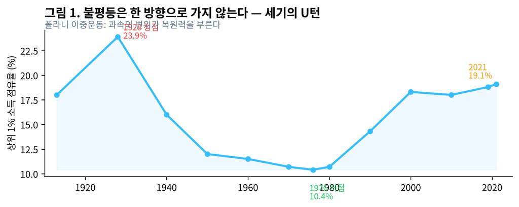

그림 1: 미국 상위 1% 세전 국민소득 점유율(1913–2021). 1928년 정점(23.9%) → 대압축기 저점(1976년 10.4%) → 재상승(2021년 19%). 한 방향 추세가 아니라 세대 규모의 ’되돌아옴’이다. 출처: World Inequality Database(Piketty·Saez·Zucman), 근사 십년값.

1928년의 극단(23.9%)은 대공황·뉴딜·전시 통제·강한 노조라는 **복원력의 폭발**을 불렀고, 상위 점유율은 반세기에 걸쳐 10%까지 되돌아왔다(대압축, Great Compression). 그 뒤 1980년대부터 규제완화·세계화로 다시 자유화 방향으로 밀렸고, 오늘 우리는 두 번째 정점 부근에 있다. 이 U자 곡선은 ’불평등이 계속 커진다’는 단조 서사도, ’시장이 알아서 평준화한다’는 쿠즈네츠 서사도 아니다. **평형을 지나쳐 되튀는 진자**다. $k=0$이라면 이런 반전은 없다.

# 3 데이터 2 — 민주주의의 감쇠진동

후쿠야마의 명제는 소득이 아니라 체제에 관한 것이었다. 그러니 체제 지표로도 확인하자. 전 세계 전자민주주의 지수(V-Dem)의 궤적이다.

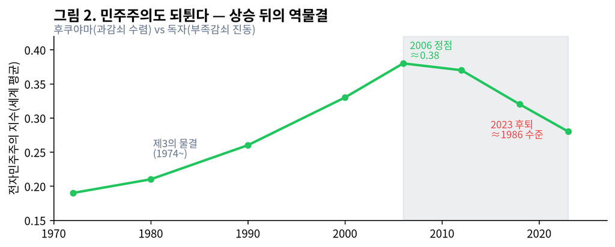

# 4 모형 — 세 개의 감쇠 영역

같은 방정식, 다른 $c$(감쇠). 판별식 $c^2$ 대 $4mk$가 체제의 운명을 가른다. 아래는 개념 모형이며 **예측이 아니다** — 세 목소리가 각각 어떤 파라미터 가정에 대응하는지를 보이기 위한 것이다.

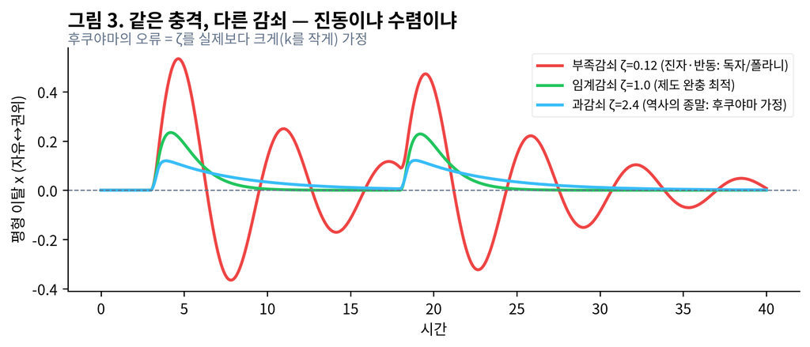

그림 3: 구동 충격 F(t) 두 번(위기)을 받은 정치체제의 반응. 부족감쇠(독자·폴라니): 평형을 지나쳐 되튀며 권위 반동→수정자유주의로 진동. 과감쇠(후쿠야마 가정): 진동 없이 서서히 평형 수렴 = ‘역사의 종말’. 임계감쇠: 오버슈트 없이 가장 빠른 안정. 개념 모형이며 실측·예측이 아님.

세 곡선은 같은 위기 충격을 받았지만 운명이 다르다. 후쿠야마의 세계(과감쇠, 파랑)에서는 충격이 와도 진동 없이 평형으로 미끄러진다 — 역사가 끝난다. 그러나 실제 데이터(그림 1·2)는 붉은 곡선, 즉 **부족감쇠**에 가깝다: 자유화가 권위 반동을 부르고, 그 반동이 다시 되튄다. 임계감쇠(초록)는 오버슈트 없이 가장 빠르게 안정되는 이상적 상태로, 감쇠 $c$(제도 완충)를 설계로 키웠을 때만 도달한다.

여기에 물리학이 하나 더 경고한다. **공명(resonance)** 이다. 구동 충격의 주기가 체제의 고유진동수 $\omega_0=\sqrt{k/m}$에 가까워지면 진폭이 폭발한다. 위기가 체제의 자연 주기와 맞물리는 순간 급변(파시즘 1930년대 같은)이 일어난다는 뜻이다. 진자의 존재는 ’완만한 왕복’을 보장하지 않는다.

# 5 진자가 안 돌아올 때 — 회복이냐, 새 세계냐

여기까지의 진자 그림에는 함정이 하나 있다. 수학적으로 진자는 **언제나** 제자리로 돌아온다. 하지만 현실의 자연과 사회는 그렇지 않을 수 있다. “트럼프 같은 태풍이 앞으로 더 자주 올까? 자연은 원래대로 회복될까, 아니면 다 부서지고 새 판이 짜일까?” — 이 질문은 진자 밖, 생태학의 영역이다.

가장 쉬운 그림은 **밥그릇 속의 공**이다.

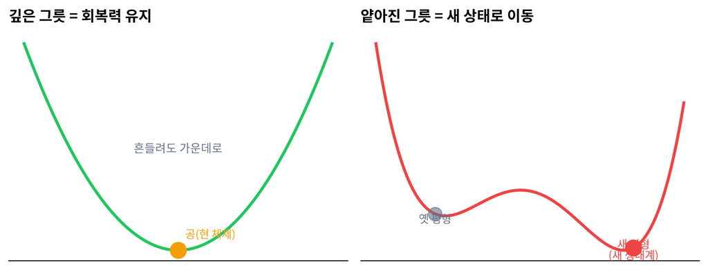

그림 4: 밥그릇(분지) 비유. 왼쪽: 그릇이 깊으면 공은 아무리 흔들려도 가운데로 되돌아온다(회복력). 오른쪽: 그릇이 얕아지고 옆에 새 그릇이 생기면, 세게 밀린 공은 언덕을 넘어 ’다른 그릇’에 갇힌다(레짐 시프트). 한번 넘어가면 원인을 없애도 잘 돌아오지 않는다(이력현상). 개념 도해.

**두 갈래 결말이 있다.**

- **회복.** 그릇이 깊으면(제도가 튼튼하면), 아무리 큰 태풍이 와도 공은 가운데로 되돌아온다. huen의 낙관 — “자유주의 다음에 수정자유주의” — 은 그릇이 깊다는 가정이다.
- **새 세계(레짐 시프트).** 그릇이 얕아지면, 한 번의 큰 충격이 공을 언덕 너머 **다른 그릇**으로 넘겨버린다. 그러면 새 평형에 갇힌다. 무서운 건 여기다 — **원인을 없애도 잘 안 돌아온다.** 오염을 멈춰도 녹조가 낀 호수는 다시 맑아지지 않는다. 이걸 이력현상이라 부른다.

그럼 “태풍이 더 자주 오나?”의 답은? **그릇이 얕아지고 있다는 신호일 수 있다.** 자연에는 유명한 조기경보가 있다: 전환점이 가까울수록 (1) 충격에서 **회복이 자꾸 느려지고** (2) 평소 **흔들림(분산)이 커지고** (3) 두 상태 사이를 **깜빡거린다.** 즉 극단 정치가 잦아지는 것 자체가 원인이 아니라, 회복력이 닳고 있다는 **증상**일 수 있다.

마지막으로, “다 부서지고 새 생태계”에 대한 자연의 냉정한 답. 자연은 파괴와 재생을 반대말로 보지 않는다. **같은 사건을 시간만 길게 본 것**이다. 공룡이 죽어야 포유류가 커지고, 산불은 파괴이자 갱신이다. 다만 새 생태계가 **더 나은** 생태계라는 보장은 없다. 레짐 시프트 뒤의 세계는 대개 더 단순하고, 다양성이 낮고, 소수가 지배한다. 봉건제도 아주 안정적인 상태였다. 죽음에 가까운 안정일 뿐.

그래서 결론은 SP21의 처방과 같다. 우리가 할 수 있는 일은 진자를 멈추는 게 아니라(불가능하다) **그릇을 깊게 유지하는 것** — 제도라는 회복력이다. 그리고 AI는 이 그릇을 깊게 파는 삽도, 얕게 긁는 갈퀴도 될 수 있다.

# 6 경계에서만 나오는 인사이트

물리학과 정치학을 교차시키자, 각 분야 단독으로는 나오지 않는 명제가 도출된다.

- **정치학에게**: ’반동’은 도덕적 낙인이 아니라 **크기를 가진 예측 가능한 양**이 된다. 복원력 $\approx kx$이므로, 자유화·불평등의 변위 $x$가 클수록 뒤따를 권위 반동도 커진다. 트럼프의 크기는 그 이전 자유화·불평등의 크기에 대한 함수다. 반동을 욕할 게 아니라 **변위를 관리**해야 한다는 처방이 나온다.
- **물리학에게**: 진동자에는 목적이 없지만, 정치와 결합하면 $c$(감쇠)와 $k$(복원력)가 **제도 설계로 바뀌는 변수**가 된다. 오버슈트(권위주의 급반동)를 줄이려면 진자를 멈추려 하지 말고 — 그건 불가능하다 — 감쇠를 키워야 한다: 사법 독립, 연방제, 언론, 완충적 재분배. 이것이 폴라니가 말한 ’사회의 자기보호’의 공학적 번역이다.
- **후쿠야마 오판의 정확한 좌표**: 그는 방향(장기적으로 자유민주주의가 우세)에서 부분적으로 옳았지만, $k\to 0$을 가정해 **진동항을 지웠다.** 감쇠진동은 장기 추세(상방 드리프트)와 단기 오버슈트(역물결)를 동시에 갖는다. 그는 드리프트만 보고 진동을 못 봤다.

그리고 이것은 이 저널의 이전 화두(SP20 — AI와 사회이동성)와 곧장 이어진다. **AI는 이 방정식에서 $F$인가, $k$인가, $c$인가?** AI가 불평등 변위 $x$를 키우면(자본 프런티어) 뒤따를 복원력=권위 반동을 키우는 구동력 $F$가 된다. 반대로 공공AI가 접근·소유·재분배로 설계되면 감쇠 $c$를 키워 오버슈트를 줄이는 완충재가 된다. 같은 기술이 진자를 흔드는 손도, 잡아주는 손도 될 수 있다 — 부호는 기술이 아니라 제도가 정한다.

**경고반대 해석과 성립하지 않는 범위**

- **진동자는 1차 근사이지 증명이 아니다.** 데이터가 오실레이션을 보인다는 사실이 정치가 선형 조화진동자와 ’구조적으로 동일’함을 증명하지는 않는다(상관 ≠ 동형). $k$와 $c$를 상수로 둔 것은 과단순화이며, 실제 정치는 비선형·다차원·경로의존적이다. 이력현상(hysteresis)이 있으면 체제는 같은 평형으로 돌아오지 않는다.
- **후쿠야마 재반론.** 100년 단위로 보면 민주국가 수와 인권 규범은 순증했다. 감쇠진동에 상방 드리프트가 겹친 형태라면, 그의 ‘방향성’ 주장이 완전히 틀린 것은 아니다. 되튐이 있다고 종착점이 없다는 뜻은 아니다.
- **모형은 예측이 아니다.** 그림 3은 세 목소리를 파라미터로 번역한 개념 도해이며, 미래 정치를 예측하지 않는다. 그림 1·2의 연도값은 공표 자료를 근사·재구성한 것으로, 정밀 계량분석은 WID·V-Dem·Freedom House 원자료로 후속돼야 한다.
- **냉소 댓글의 반쪽 진실.** 관측자의 전향은 계의 진동을 반증하지 못하지만, 그렇다고 그의 예측력을 보증하지도 않는다. 신념을 데이터에 맞춰 고치는 능력(정직)과 미래를 맞추는 능력(예측)은 별개의 축이다.

# 7 참고 문헌

- Francis Fukuyama, *The End of History and the Last Man*(1992); NYT 인터뷰(2026-08-31), 회고록 *In the Realm of the Last Man*.
- Karl Polanyi, *The Great Transformation*(1944) — 이중운동(double movement).
- Thomas Piketty, Emmanuel Saez, Gabriel Zucman, World Inequality Database(wid.world) — 미국 상위 1% 소득 점유율.
- V-Dem Institute, *Democracy Report 2024: Democracy Winning and Losing at the Ballot*.
- Freedom House, *Freedom in the World 2024* — 18년 연속 세계 자유도 하락.
- Samuel Huntington, *The Third Wave: Democratization in the Late Twentieth Century*(1991).
- 감쇠·구동 조화진동자와 공명: 표준 고전역학(예: Marion & Thornton, *Classical Dynamics*).
- 최낙초, *Public AI as Social Infrastructure*(2026, 작업본); Insight Lab SP20.